# L23

# Upgrades and Feature Flags

## FFs

- Multiple code paths which you can select at runtime which code path is used
- Can use ffs to update code without rolling out a feature
- Makes sure change affects all customers at once
- Store in DB not in config file because config files not easy to check on the fly
- Can use `rollout` gem to cover main cases

### Upgrading With Inconsistent DB Schemas

- Without FFs: Can bring service down and upgrade it
- Procedure to use FFs:
  1. Apply nondestructive migration
  2. Deploy code protected by ff
  3. Flip feature flag on; if disasters flip it back
  4. Once all records moved, deploy new code without ff
  5. Apply destructive migration (remove old columns)
     - Have an ‘undo’ plan for destructive steps
  - eg:

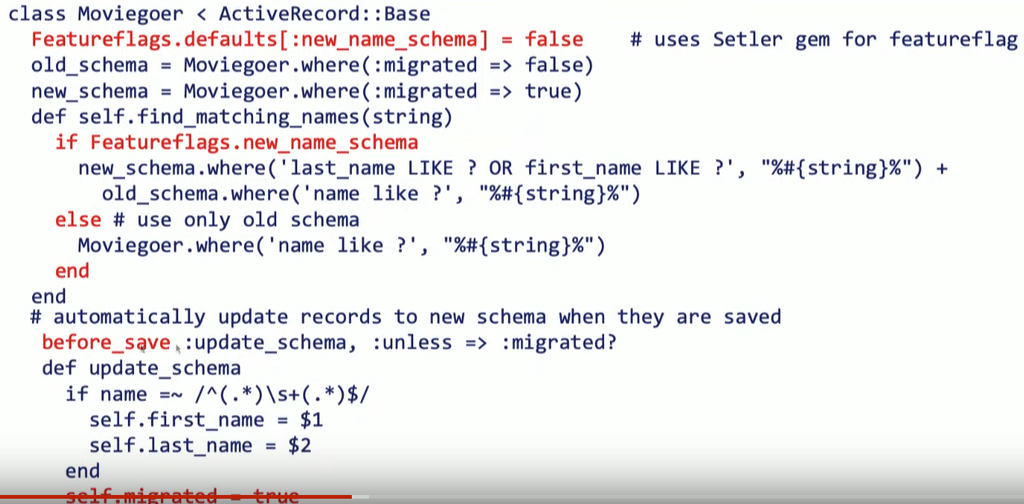

    - Lazy migration strategy
    - Can also have another OLP to automatically passively migrate records
  - Good because can update with the app running
  - Can always turn off the ff if things go wrong
  - Once completely migrated, can remove conditional checks on ff and ff itself as well as db columns migrated and no longer used or added for migration

## Other Uses of FFs

- Preflight checking ≙ gradual rollout of feature to increasing numbers of users
- A/B testing
- Complex feature whose code spans multiple deploys
- Eg use case: password algorithm update

## Monitoring

- In development (profiling) ≙ identify possible performance/stability problems before they get to prod
- In production
  - Internal ≙ instrumentation embedded in app and/or framework
  - External ≙ active probing by other site(s)
    - Detects if site is down
    - Detects if site is slow for reasons outside measurement boundary of internal monitoring
- Can make cucumber tests for monitoring

## Stress/Load Testing

- Assess how far you can push a system
  - Before performance (apdex 95th percentile response) becomes unacceptable
  - Before it gasps and dies
  - To expose longevity bugs like memory links
- Can help assess a bottleneck
- Can be simple or sophisticated

### Resource Leaks

- Leaked memory can be fixed temporarily by rebooting
  - Can do automatically with ‘rejuvenation’ / ‘rolling reboot’
- Can run out of db rows
  - PaaS often allows minimally disruptive upgrade-in-place
- Database pollution from unclaimed objects (eg: shopping carts)
  - Can run periodic ‘stale object’ sweepers that look at `updated_at` to purge

## Caching

- Avoid touching db if answer to query hasn’t changed
- Avoid re-rendering a page or partial if the underlying objects on which they depend haven’t changed
- Expire stale cached versions when they become invalid
- Goal ≙ understand what the ‘unit of caching’ is and how to expire things

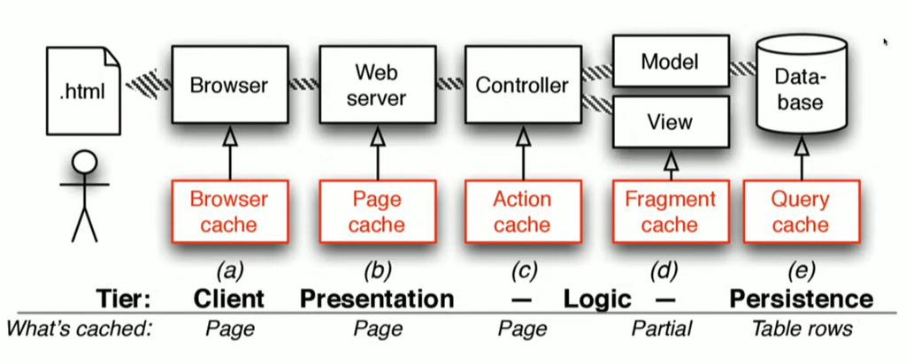

- Stored in key-value store
  - `ActiveSupport::Cache::Store` facade: `read`, `write`, `delete`, `exist?`, `fetch`
  - Out-of-the-box support: memcached, Redis, file system
  - `ActiveSupport::Cache::NullStore` uses null-object pattern to ‘disable’ caching in development and test envs

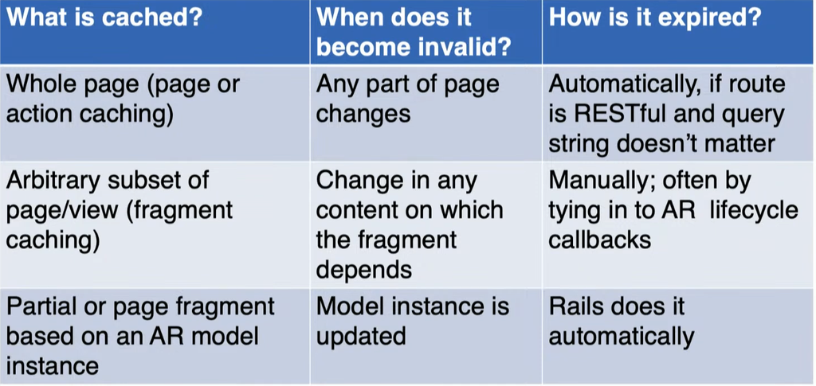

### Conditions

- Page caching bypasses controller action with `caches_page :index`
  - Only should be done on static pages since it doesn’t touch the controller at all
- Action caching runs controller filters first
- **Note**: caching is based on page URL without query params so don’t mix filter and non-filter code paths in same action

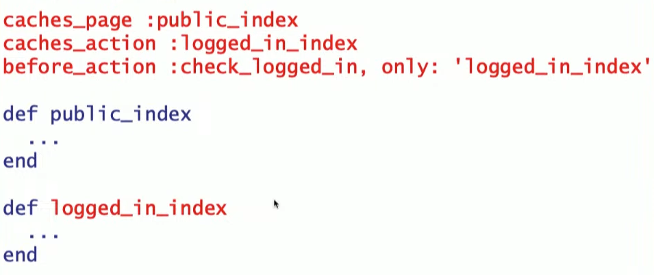

- Fragment caching is almost always helpful

### Fragment Caching for Views

- Name the part of the view you want to cache (partial, collection, etc.)
- Wrap with `< % cache 'name' do %> ... < % end %>` to ‘memoize’
- Makes Rails look in cache store to cache that specific cache block
  - Could also cache on an active record object to update dynamically
- Can use a cache sweeper to observe a model and look for anything that will invalidate the cache
  - eg:

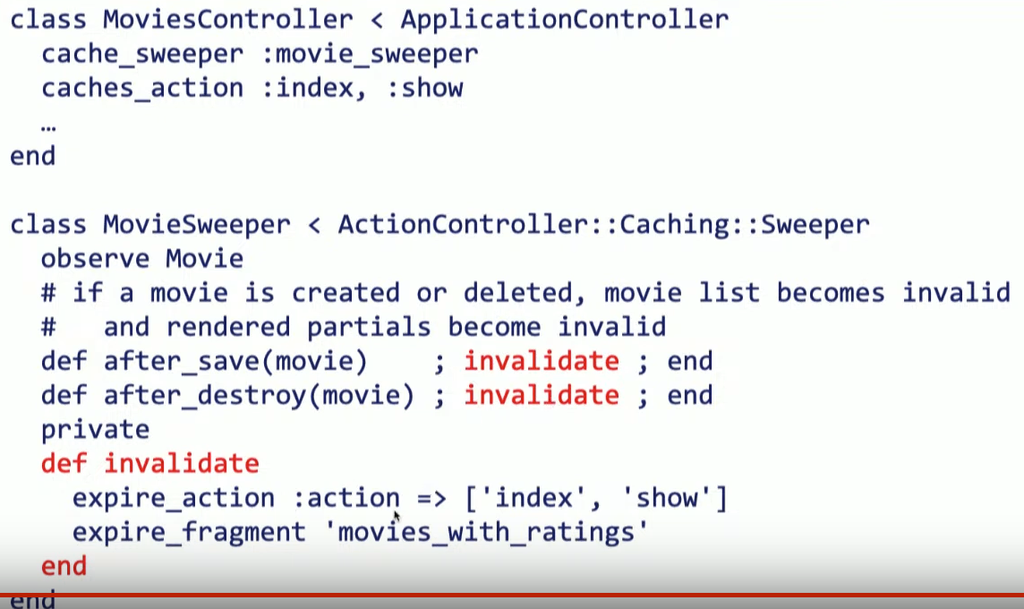

- Always better to expire something valid than not expire something that is invalid

## Database Indices

- Index ≙ hash-like data structure that speeds up access when searching DB by column other than the PK
- Don’t have an index on every column b/c all indices must be updated on each table when modifying
- To index:
  - Foreign key columns
  - Columns that appear in `where()` clauses of `ActiveRecord` queries
  - Columns on which you sort
- `rails_index` is a gem that helps identify missing indices (and unnecessary ones)
- Probably a better idea to over-index than under-index